# g1a3

## Assignment 3

Authors: Jonathan Ashbeck, Kelly Lake, Audrey Moore, Laura Sikes, Tommy Steele, & Ecil Teodoro  
Class: STA6349  
Group: 1  
Instructor: Dr. Samantha Seals  
Date: March 23, 2024

## Data Exploration

The bald_eagles dataset was accessed through the bayesrules package in R Studio. The dataset contains information on bald eagles observed between 1981 and 2017.

```
[1] 37
```

| year | count | hours | count_per_hour | count_per_week |
| --- | --- | --- | --- | --- |
| 1981 | 0 | 167 | 0.000000000 | 0.0000000 |
| 1982 | 0 | 164 | 0.000000000 | 0.0000000 |
| 1983 | 0 | 168 | 0.000000000 | 0.0000000 |
| 1984 | 1 | 178 | 0.005617978 | 0.9438202 |
| 1985 | 2 | 143 | 0.013986014 | 2.3496503 |
| 1986 | 1 | 182 | 0.005494505 | 0.9230769 |

The dataset features five variables with 37 observations.

## Model Selection

The group selected the Gamma-Poisson model for this project, as the Poisson distribution models the number of events occurring in a fixed interval, and the Gamma distribution prior models the rate $(\lambda)$ of the Poisson process.

## Data Visualization

The group plotted the eagle count per hour over time in years, overlaid with the raw counts over the same time frame.

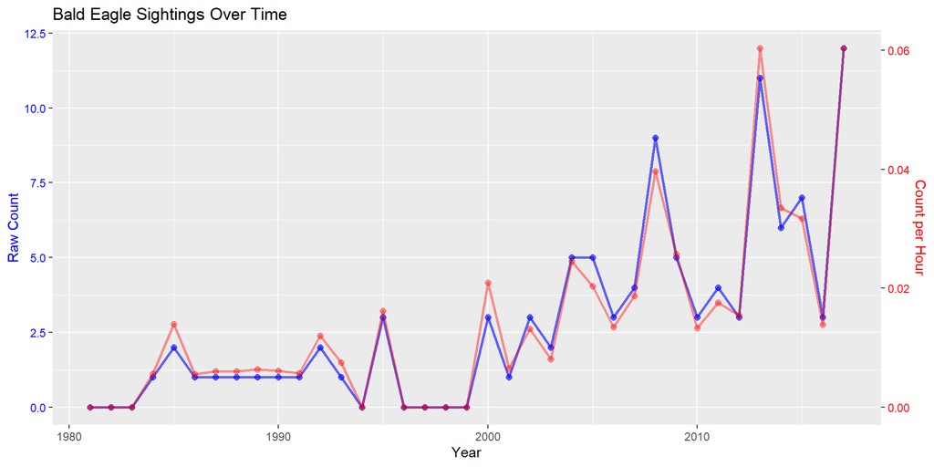

## Posterior for 1981 - 1999

Expected Values Based on World Wildlife Fund: ~4 sightings per year, ranging from 0 to 12.

$y_i | \lambda \sim \text{Poi}(4)$ $E[\lambda] = s/r \approx 4 \implies s = 4r$

Choosing the Prior: $\lambda \sim \text{Gamma}(3, 0.75)$

Deriving the Posterior: $\lambda | \vec{y} \sim \text{Gamma}(18, 19.75)$

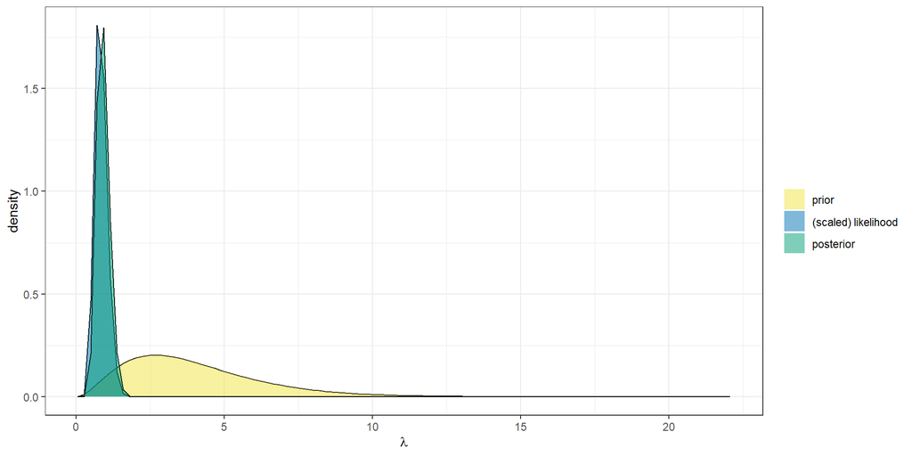

## Posterior for 2000 - 2017

**Expected Values Based on World Wildlife Fund:**

Used 10 and 1 as prior shape and rate parameters respectively.

```
Alpha Posterior 00-17:  99
```

```
Beta Posterior 00-17:  19
```

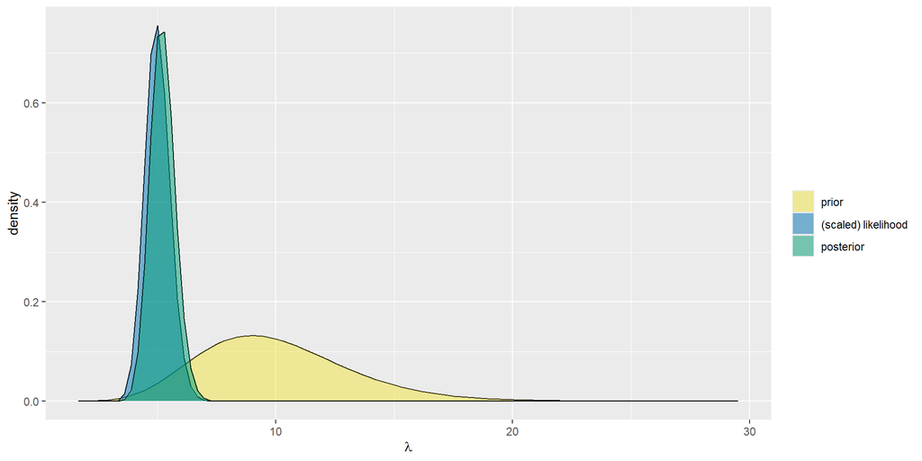

## Posterior for 1981 - 2017

```
Alpha Prior all:  0.8627378
```

```
Beta Prior all:  0.3069356
```

```
Alpha Posterior all:  104.8627
```

```
Beta Posterior all:  37.30694
```

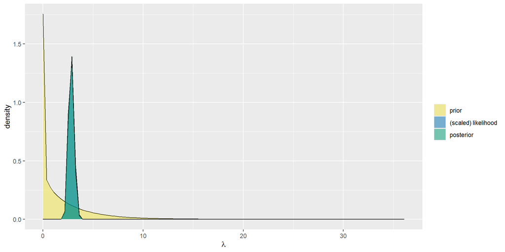

## Comparison of All Posteriors Derived

Since each subgroup did not use the same prior for their respective models, we did not expect to see the same result for finding the posterior for all data versus the two separate chunks of time.

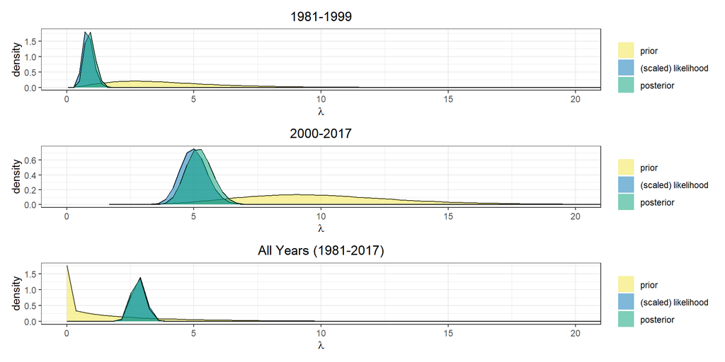